# Introduction to R

May 17, 2016

## Overview of the R Project

## Lesson Plan

### R U Ready?

- What the R Language for Statistical Computing is
- R's capabilities and it's limitations
- What types of problems you might want to use R with
- How to manage data with open source R
- How to develop models and write functions in R

## What is R?

### Why should I care?

- R is a successor of the S Language, originated at Bell Labs AT&T
- Based on the Scheme interpreter
- Originally designed by two University of Auckland Professors for their introduction to statistics course

[figure not shown]

## R Philosophy

### What R Thou?

R follows the [Unix philosophy](http://en.wikipedia.org/wiki/Unix_philosophy)

> Write programs that do one thing and do it well. Write programs to work together.
- R is extensible with more than 9,000 packages available at CRAN (http://crantastic.org/packages)
- R, like it's inspiration, Scheme, is a functional programming language
- R is lazy, and lazy evaluation can be used to interface to other languages
- R is a highly interpreted dynamically typed language, allowing you to mutate variables and analyze datasets quickly, but is significantly slower than low-level, statically typed languages like C or Java
- R has a high memory footprint, and can easily lead to crashes if you aren't careful

## Development Environments

### Where to Write R Code

- The most popular integrated development environment for R is [RStudio](https://www.rstudio.com/)
- The RStudio IDE is entirely html/javascript based, so completely cross-platform
- RStudio Server for cloud instances
- Developers of RStudio have also written a plethora of useful R packages
- For Windows machines, we have recently announced the general availability of [R Tools for Visual Studio, RTVS](https://www.visualstudio.com/en-us/features/rtvs-vs.aspx)
- RTVS will support connectivity to Azure and SQL Server very soon
- RTVS has great debugging support

## Weaknesses of R

### Where R Falls Short

- It is designed by statisticians
- Inefficient at element-by-element computations
- May make large demands on system resources, namely memory
- Data capacity limited by memory
- Single-threaded

## Some Essential Open Source Packages

- There are over 1,000 R packages to choose from, what do I start with?
- Data Management: `dplyr`, `tidyr`, `data.table`
- Visualization: `ggplot2`, `ggvis`, `htmlwidgets`, `shiny`
- Data Importing: `haven`, `RODBC`
- Other favorites; `magrittr`, `rmarkdown`, `caret`

## R Foundations

## Command line prompts

| Symbol | Meaning |
| --- | --- |
| `>` | ready for a new command |
| `+` | awaiting the completion of an existing command |

## I'm Lost!

### Getting Help with R

- [Stack Overflow](http://stackoverflow.com/questions/tagged/r)
- [Cross Validated, R](http://stats.stackexchange.com/)
- [R Reference Card](https://cran.r-project.org/doc/contrib/Short-refcard.pdf)
- [RStudio Cheat Sheets](https://www.rstudio.com/resources/cheatsheets/)
- [R help mailing list and archives](https://stat.ethz.ch/mailman/listinfo/r-help)
- [CRAN Task Views](https://cran.r-project.org/web/views/)
- [Crantastic](http://crantastic.org/)
- [Revolutions Blog](http://blog.revolutionanalytics.com/)
- [R-Bloggers](http://www.r-bloggers.com/)

## Quick Tour of Things You Need to Know

### Data Structures

- R's data structures can be described by their dimensionality, and their type.

|  | Homogeneous | Heterogeneous |
| --- | --- | --- |
| 1d | Atomic vector | List |
| 2d | Matrix | Data frame |
| nd | Array |  |

## Quick Tour of Things You Need to Know

### Data Types

- Atomic vectors come in one of four types
- `logical` (boolean). Values: `TRUE` | `FALSE`
- `integer`
- `double` (often called numeric)
- `character`
- Rare types:
- `complex`
- `raw`

## Lab 1: R Data Types

## Data Manipulation with the dplyr Package

## Overview

At the end of this session, you will have learned:

- How to manipulate data quickly with `dplyr` using a very intuitive 'grammar'
- How to use `dplyr` to perform common exploratory and manipulation procedures
- Apply your own custom functions to group manipulations `dplyr` with `mutate()`, `summarise()` and `do()`
- Connect to remote databases to work with larger than memory datasets

## Why use dplyr?

### The Grammar of Data Manipulation

- R comes with a plethora of base functions for data manipulation
- `dplyr` makes data manipulation easier by providing a few functions for the most common tasks and procedures
- `dplyr` achieves remarkable speed-up gains by using a C++ backend
- `dplyr` has multiple backends for working with data stored in various sources: SQLite, MySQL, bigquery, and more
- `dplyr` was inspired to give data manipulation a simple, cohesive grammar (similar philosophy to `ggplot` - grammar of graphics)
- the recent package `dplyrXdf` brings much of the same functionality of `dplyr` to `XDF` data

## Manipulation verbs

**filter**

select rows based on matching criteria

**slice**

select rows by number

**select**

select columns by column names

**arrange**

reorder rows by column values

**mutate**

add new variables based on transformations of existing variables

**transmute**

transform and drop other variables

## Aggregation verbs

**group_by**

identify grouping variables for calculating groupwise summary statistics

**count**

count the number of records per group

**summarise**

calculate one or more summary functions per group, returning one row of results per group (or one for the entire dataset)

## Viewing Data

- `dplyr` includes a wrapper called `tbl_df` makes df into a 'local df' that improves the printing of dataframes in the console
- if you want to see more of the data you can still coerce to `data.frame`

```r
library(dplyr)
bankData <- read.table("data/bank-full.csv",
                       header = T, sep = ";",
                       stringsAsFactors = F)
(bankData <- tbl_df(bankData))
```

```
## Source: local data frame [45,211 x 17]
##
##    age          job  marital education default balance housing loan
## 1   58   management  married  tertiary      no    2143     yes   no
## 2   44   technician   single secondary      no      29     yes   no
## 3   33 entrepreneur  married secondary      no       2     yes  yes
## 4   47  blue-collar  married   unknown      no    1506     yes   no
## 5   33      unknown   single   unknown      no       1      no   no
## 6   35   management  married  tertiary      no     231     yes   no
## 7   28   management   single  tertiary      no     447     yes  yes
## 8   42 entrepreneur divorced  tertiary     yes       2     yes   no
## 9   58      retired  married   primary      no     121     yes   no
## 10  43   technician   single secondary      no     593     yes   no
## .. ...          ...      ...       ...     ...     ...     ...  ...
## Variables not shown: contact (chr), day (int), month (chr), duration
##   (int), campaign (int), pdays (int), previous (int), poutcome (chr), y
##   (chr)
```

## Filtering and Reordering Data

## Subsetting Data

- `dplyr` makes subsetting by rows very easy
- The `filter` verb takes conditions for filtering rows based on conditions

```r
filter(bankData,
       month %in% c("april", "may", "jun"),
       default == "yes")
```

```
## Source: local data frame [351 x 17]
##
##    age          job  marital education default balance housing loan
## 1   42 entrepreneur divorced  tertiary     yes       2     yes   no
## 2   55     services divorced secondary     yes       1     yes   no
## 3   51       admin.   single secondary     yes      -2      no   no
## 4   33   technician  married secondary     yes      72     yes   no
## 5   33  blue-collar   single secondary     yes     -60      no   no
## 6   60      retired  married secondary     yes      15      no   no
## 7   35 entrepreneur  married secondary     yes     204     yes   no
## 8   41  blue-collar   single   primary     yes    -137     yes  yes
## 9   54     services  married secondary     yes       0     yes   no
## 10  52  blue-collar divorced   primary     yes    -183     yes   no
## .. ...          ...      ...       ...     ...     ...     ...  ...
## Variables not shown: contact (chr), day (int), month (chr), duration
##   (int), campaign (int), pdays (int), previous (int), poutcome (chr), y
##   (chr)
```

## Exercise

Your turn:

- How many defaults in the dataset?
- How many of the entrepeneurs that defaulted were also divorced?

## Solution

```r
defaults <- filter(bankData, default == "yes")
nrow(defaults)
```

```
## [1] 815
```

```r
brokeEntrepreneurs <- filter(bankData,
                             job == "entrepreneur",
                             marital == "divorced",
                             default == "yes")
nrow(brokeEntrepreneurs)
```

```
## [1] 6
```

## Select a set of columns

- You can use the `select()` verb to specify which columns of a dataset you want
- This is similar to the `keep` option in SAS's data step.
- Use a colon `:` to select all the columns between two variables (inclusive)
- Use `contains` to take any columns containing a certain word/phrase/character

## Select Example 1

```r
select(bankData, age, job, default, balance, housing)
```

```
## Source: local data frame [45,211 x 5]
##
##    age          job default balance housing
## 1   58   management      no    2143     yes
## 2   44   technician      no      29     yes
## 3   33 entrepreneur      no       2     yes
## 4   47  blue-collar      no    1506     yes
## 5   33      unknown      no       1      no
## 6   35   management      no     231     yes
## 7   28   management      no     447     yes
## 8   42 entrepreneur     yes       2     yes
## 9   58      retired      no     121     yes
## 10  43   technician      no     593     yes
## .. ...          ...     ...     ...     ...
```

## Select: Other Options

**starts_with(x, ignore.case = FALSE)**

name starts with `x`

**ends_with(x, ignore.case = FALSE)**

name ends with `x`

**matches(x, ignore.case = FALSE)**

selects all variables whose name matches the regular expression `x`

**num_range("V", 1:5, width = 1)**

selects all variables (numerically) from `V1` to `V5`.

You can also use a `-` to drop variables.

## Reordering Data

- You can reorder your dataset based on conditions using the `arrange()` verb

```r
arrange(bankData, balance, default)
```

```
## Source: local data frame [45,211 x 17]
##
##    age           job  marital education default balance housing loan
## 1   26   blue-collar   single secondary     yes   -8019      no  yes
## 2   49    management  married  tertiary     yes   -6847      no  yes
## 3   60    management divorced  tertiary      no   -4057     yes   no
## 4   43    management  married  tertiary     yes   -3372     yes   no
## 5   57 self-employed  married  tertiary     yes   -3313     yes  yes
## 6   39 self-employed  married  tertiary      no   -3058     yes  yes
## 7   40    technician  married  tertiary     yes   -2827     yes  yes
## 8   52    management  married  tertiary      no   -2712     yes  yes
## 9   49   blue-collar   single   primary     yes   -2604     yes   no
## 10  51    management divorced  tertiary      no   -2282     yes  yes
## .. ...           ...      ...       ...     ...     ...     ...  ...
## Variables not shown: contact (chr), day (int), month (chr), duration
##   (int), campaign (int), pdays (int), previous (int), poutcome (chr), y
##   (chr)
```

## Exercise

Use `arrange()` to sort on the basis of `y`, `marital`, `job` (in descending order), and `balance`

## Solution

```r
arrange(bankData, y, marital, desc(job), balance)
```

```
## Source: local data frame [45,211 x 17]
##
##    age     job  marital education default balance housing loan   contact
## 1   26 unknown divorced secondary      no    -295     yes   no  cellular
## 2   47 unknown divorced   primary      no       0      no   no  cellular
## 3   82 unknown divorced   unknown      no       0      no   no telephone
## 4   59 unknown divorced   unknown      no      27      no   no   unknown
## 5   31 unknown divorced  tertiary      no     137      no   no  cellular
## 6   56 unknown divorced   primary      no     558      no   no   unknown
## 7   51 unknown divorced   unknown      no    1649      no   no   unknown
## 8   66 unknown divorced   unknown      no    1993     yes   no  cellular
## 9   56 unknown divorced   unknown      no    2152      no   no   unknown
## 10  53 unknown divorced  tertiary      no    2272     yes   no   unknown
## .. ...     ...      ...       ...     ...     ...     ...  ...       ...
## Variables not shown: day (int), month (chr), duration (int), campaign
##   (int), pdays (int), previous (int), poutcome (chr), y (chr)
```

## Summary

**filter**

Extract subsets of rows. See also `slice()`

**select**

Extract subsets of columns. See also `rename()`

**arrange**

Sort your data

## Transformations

- The `mutate()` verb can be used to make new columns

```r
mutate(bankData,
       DefaultFlag = ifelse(default == 'yes',
                              yes =  1,
                              no = 0)
)
```

```
## Source: local data frame [45,211 x 18]
##
##    age          job  marital education default balance housing loan
## 1   58   management  married  tertiary      no    2143     yes   no
## 2   44   technician   single secondary      no      29     yes   no
## 3   33 entrepreneur  married secondary      no       2     yes  yes
## 4   47  blue-collar  married   unknown      no    1506     yes   no
## 5   33      unknown   single   unknown      no       1      no   no
## 6   35   management  married  tertiary      no     231     yes   no
## 7   28   management   single  tertiary      no     447     yes  yes
## 8   42 entrepreneur divorced  tertiary     yes       2     yes   no
## 9   58      retired  married   primary      no     121     yes   no
## 10  43   technician   single secondary      no     593     yes   no
## .. ...          ...      ...       ...     ...     ...     ...  ...
## Variables not shown: contact (chr), day (int), month (chr), duration
##   (int), campaign (int), pdays (int), previous (int), poutcome (chr), y
##   (chr), DefaultFlag (dbl)
```

## Summarise Data by Groups

- The `group_by` verb creates a grouping by a categorical variable
- Functions can be placed inside `summarise` to create summary functions

```r
summarise(group_by(bankData, default), Num = n())
```

```
## Source: local data frame [2 x 2]
##
##   default   Num
## 1      no 44396
## 2     yes   815
```

## Example group_by 2

```r
summarise(group_by(bankData, default), ave_balance = mean(balance))
```

```
## Source: local data frame [2 x 2]
##
##   default ave_balance
## 1      no   1389.8064
## 2     yes   -137.6245
```

## Example group_by 3

```r
summarise(group_by(bankData, default),
          ave_balance = mean(balance),
          num = n()
)
```

```
## Source: local data frame [2 x 3]
##
##   default ave_balance   num
## 1      no   1389.8064 44396
## 2     yes   -137.6245   815
```

## Chaining/Piping

- A `dplyr` installation includes the `magrittr` package as a dependency
- The `magrittr` package includes a pipe operator that allows you to pass the current dataset to another function
- This makes interpreting a nested sequence of operations much easier to understand

## Standard Code

Code is executed inside-out.

```r
arrange(filter(select(bankData, age, job, education, default), default == 'yes'), job, education, age)
```

```
## Source: local data frame [815 x 4]
##
##    age    job education default
## 1   25 admin. secondary     yes
## 2   26 admin. secondary     yes
## 3   26 admin. secondary     yes
## 4   26 admin. secondary     yes
## 5   26 admin. secondary     yes
## 6   27 admin. secondary     yes
## 7   27 admin. secondary     yes
## 8   27 admin. secondary     yes
## 9   28 admin. secondary     yes
## 10  29 admin. secondary     yes
## .. ...    ...       ...     ...
```

## Reformatted

```r
arrange(
  filter(
    select(bankData, age, job, education, default),
    default == 'yes'),
  job, education, age)
```

```
## Source: local data frame [815 x 4]
##
##    age    job education default
## 1   25 admin. secondary     yes
## 2   26 admin. secondary     yes
## 3   26 admin. secondary     yes
## 4   26 admin. secondary     yes
## 5   26 admin. secondary     yes
## 6   27 admin. secondary     yes
## 7   27 admin. secondary     yes
## 8   27 admin. secondary     yes
## 9   28 admin. secondary     yes
## 10  29 admin. secondary     yes
## .. ...    ...       ...     ...
```

## With Piping

```r
bankData %>%
  select(age, job, education, default) %>%
  filter(default == 'yes') %>%
  arrange(job, education, age)
```

```
## Source: local data frame [815 x 4]
##
##    age    job education default
## 1   25 admin. secondary     yes
## 2   26 admin. secondary     yes
## 3   26 admin. secondary     yes
## 4   26 admin. secondary     yes
## 5   26 admin. secondary     yes
## 6   27 admin. secondary     yes
## 7   27 admin. secondary     yes
## 8   27 admin. secondary     yes
## 9   28 admin. secondary     yes
## 10  29 admin. secondary     yes
## .. ...    ...       ...     ...
```

## Pipe + group_by()

The pipe operator is very helpful for group by summaries

```r
bankData %>%
  group_by(job) %>%
  summarise(num = n(),
            ave_balance = mean(balance),
            num_defaults = sum(default == 'yes'),
            default_rate = num_defaults/num)
```

```
## Source: local data frame [12 x 5]
##
##              job  num ave_balance num_defaults default_rate
## 1         admin. 5171   1135.8389           74  0.014310578
## 2    blue-collar 9732   1078.8267          201  0.020653514
## 3   entrepreneur 1487   1521.4701           55  0.036987223
## 4      housemaid 1240   1392.3952           22  0.017741935
## 5     management 9458   1763.6168          164  0.017339818
## 6        retired 2264   1984.2151           26  0.011484099
## 7  self-employed 1579   1647.9709           33  0.020899303
## 8       services 4154    997.0881           75  0.018054887
## 9        student  938   1388.0608            3  0.003198294
## 10    technician 7597   1252.6321          130  0.017112018
## 11    unemployed 1303   1521.7460           30  0.023023791
## 12       unknown  288   1772.3576            2  0.006944444
```

## Pipe and Plot

As a reminder, piping can also be used for non-dplyr functions.

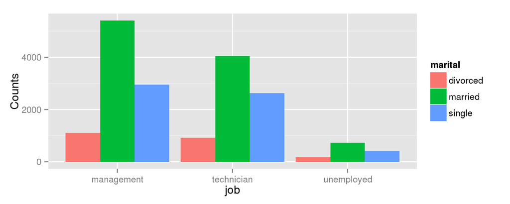

```r
library(ggplot2)
bankData %>%
  filter(job %in% c("management", "technician", "unemployed")) %>%
  group_by(job, marital) %>%
  summarise(Counts = n()) %>%
  ggplot() +
  geom_bar(aes(x = job, y = Counts, fill = marital),
           stat = 'identity', position = 'dodge')
```

## Exercise

Your turn:

- Use the pipe operator to group by job and housing status
- Calculate the counts of observations, and the average and median balance

## Solution

```r
bankData %>%
  group_by(job, housing) %>%
  summarise(Counts = n(),
            average_balance = mean(as.numeric(balance)),
            median_balance = median(as.numeric(balance)))
```

```
## Source: local data frame [24 x 5]
## Groups: job
##
##             job housing Counts average_balance median_balance
## 1        admin.      no   1989       1378.7677          445.0
## 2        admin.     yes   3182        983.9893          387.0
## 3   blue-collar      no   2684       1341.3308          421.5
## 4   blue-collar     yes   7048        978.8605          373.0
## 5  entrepreneur      no    618       1862.7023          390.0
## 6  entrepreneur     yes    869       1278.7986          339.0
## 7     housemaid      no    842       1491.1876          465.5
## 8     housemaid     yes    398       1183.3920          314.5
## 9    management      no   4780       1913.7525          600.5
## 10   management     yes   4678       1610.2076          547.0
## ..          ...     ...    ...             ...            ...
```

## Summary

**mutate**

Create transformations

**summarise**

Aggregate

**group_by**

Group your dataset by levels

**distinct**

Extract unique values (frequently used with `arrange()`)

Chaining with the `%>%` operator can result in more readable code.

## Thanks for Attending!

- Any questions?
- alizaidi@microsoft.com